# Fusión GPS–ACC en libertad (Goku 221996): bursts, mapas y validación ecológica

kurisutina132

2026-05-08

# 1 Introducción

En esta sección se integran datos de **GPS** (ráfagas de fixes) con predicciones de comportamiento derivadas de **acelerometría (ACC)** en ventanas de **2 segundos**, para un individuo en libertad (*Goku*, `device_id = 221996`) registrado entre **2023-04-17 y 2023-05-31** en la zona de **Lleida (España)**.

Los objetivos son:

1. Construir **GPS bursts** (agrupación de fixes cercanos en el tiempo).
2. Asociar a cada burst una **conducta dominante** estimada desde ACC.
3. Generar mapas “científicos” (solo puntos) con **flecha norte y escala**, en **ETRS89 / UTM 31N (EPSG:25831)**.
4. Evaluar una **validación ecológica externa**: si las etiquetas de conducta se relacionan con el movimiento entre ráfagas consecutivas (p.ej., *resting* debería asociarse a menor velocidad que *locomotion*).

# 2 Metodología

## 2.1 Datos de entrada

- CSV en libertad (GPS + SENSORS).
- CSV de predicciones de ACC en ventanas de 2 s (`*_predictions_2s.csv`).

## 2.2 Construcción de GPS bursts

Se define un burst como un conjunto de fixes GPS consecutivos separados por menos de `burst_gap_sec` segundos. Si el gap supera ese umbral, se inicia un nuevo burst.

## 2.3 Fusión ACC–GPS y asignación única

Para asociar ACC con bursts, se usa un buffer ±`acc_buffer_sec`. Para evitar doble conteo, cada ventana ACC se asigna al burst cuyo centro temporal (`burst_mid`) sea más cercano.

## 2.4 Conducta dominante y filtro de calidad

En cada burst se calcula:

- `dominant_behavior`: conducta con mayor porcentaje.
- `dominant_pct`: porcentaje de la conducta dominante.
- `dominance_gap`: diferencia entre la 1ª y 2ª conducta (top1 - top2).
- `n_total`: cantidad de ventanas ACC asociadas al burst.

Se define `beh_quality`:

- `no_match`: sin ACC asociado.
- `low_n`: `n_total < 2`.
- `weak_dominance`: `dominant_pct < 60`.
- `ambiguous`: `dominance_gap < 20`.
- `good`: cumple todos los criterios.

## 2.5 Periodo con ACC

Para evitar sesgo de muestreo, se define el subperiodo “con ACC” usando el rango temporal de `acc_pred$date_time`, y se construyen dos productos:

- **GPS-only:** periodo completo.
- **GPS+ACC:** subperiodo con ACC.

# 3 Pipeline reproducible (carga, bursts, merge, mapas)

```r
free_csv <- "C:/Users/kuris/OneDrive/Documentos/ACC/data/en libertad/Goku_221996_20230417_20230531.csv"
pred_dir <- "C:/Users/kuris/OneDrive/Documentos/results/free"
out_dir  <- "C:/Users/kuris/OneDrive/Documentos/ACC/Free Free-rangung bustard clasifications"
out_prefix <- "Goku_221996_20230417_20230531"

dir.create(out_dir, recursive = TRUE, showWarnings = FALSE)

out_csv  <- file.path(out_dir, paste0(out_prefix, "_gps_bursts_with_behavior.csv"))
out_xlsx <- file.path(out_dir, paste0(out_prefix, "_gps_bursts_with_behavior.xlsx"))
```

```r
free_raw <- readr::read_csv(free_csv, show_col_types = FALSE) %>%
  mutate(
    device_id = as.integer(device_id),
    UTC_datetime = as.POSIXct(UTC_datetime, tz = "UTC")
  )

pred_path <- list.files(
  pred_dir,
  pattern = paste0("^", out_prefix, "_predictions_2s\\.csv$"),
  full.names = TRUE,
  ignore.case = TRUE
)
stopifnot(length(pred_path) == 1)
pred_path <- pred_path[1]

pred_tbl2 <- read.csv(pred_path, stringsAsFactors = FALSE)
stopifnot(all(c("device_id","date_time","predictions") %in% names(pred_tbl2)))

pred_tbl2$date_time <- as.POSIXct(pred_tbl2$date_time, tz = "UTC")

acc_pred <- pred_tbl2 %>%
  transmute(
    device_id = as.integer(device_id),
    date_time,
    predictions = as.character(predictions)
  )

acc_min <- min(acc_pred$date_time, na.rm = TRUE)
acc_max <- max(acc_pred$date_time, na.rm = TRUE)
```

```r
haversine_m <- function(lon1, lat1, lon2, lat2) {
  R <- 6371000
  to_rad <- pi / 180
  lon1 <- lon1 * to_rad; lat1 <- lat1 * to_rad
  lon2 <- lon2 * to_rad; lat2 <- lat2 * to_rad
  dlon <- lon2 - lon1
  dlat <- lat2 - lat1
  a <- sin(dlat/2)^2 + cos(lat1) * cos(lat2) * sin(dlon/2)^2
  c <- 2 * atan2(sqrt(a), sqrt(1 - a))
  R * c
}
```

```r
burst_gap_sec <- 5

gps <- free_raw %>%
  filter(datatype == "GPS") %>%
  arrange(device_id, UTC_datetime) %>%
  group_by(device_id) %>%
  mutate(
    dt_sec = as.numeric(difftime(UTC_datetime, lag(UTC_datetime), units = "secs")),
    step_m = haversine_m(lag(Longitude), lag(Latitude), Longitude, Latitude),
    speed_m_s_from_coords = step_m / dt_sec,
    speed_km_h_from_coords = speed_m_s_from_coords * 3.6,
    new_burst = is.na(dt_sec) | dt_sec > burst_gap_sec,
    gps_burst_id = cumsum(new_burst)
  ) %>%
  ungroup()

gps_bursts <- gps %>%
  group_by(device_id, gps_burst_id) %>%
  summarise(
    start_time = min(UTC_datetime),
    end_time   = max(UTC_datetime),
    duration_sec = as.numeric(difftime(end_time, start_time, units = "secs")),
    n_fixes = n(),
    hdop_med = median(hdop, na.rm = TRUE),
    satcount_med = median(satcount, na.rm = TRUE),
    lat_med = median(Latitude, na.rm = TRUE),
    lon_med = median(Longitude, na.rm = TRUE),
    alt_med = median(Altitude_m, na.rm = TRUE),
    dist_m_sum = sum(step_m, na.rm = TRUE),
    speed_km_h_tag_med = median(speed_km_h, na.rm = TRUE),
    speed_km_h_coords_med = median(speed_km_h_from_coords, na.rm = TRUE),
    .groups = "drop"
  ) %>%
  arrange(device_id, start_time)

gps_bursts
```

| device_id | gps_burst_id | start_time | end_time | duration_sec | n_fixes | hdop_med | satcount_med | lat_med | lon_med | alt_med | dist_m_sum | speed_km_h_tag_med | speed_km_h_coords_med |
| --- | --- | --- | --- | --- | --- | --- | --- | --- | --- | --- | --- | --- | --- |
| 221996 | 1 | 2023-04-17 14:43:41 | 2023-04-17 14:43:45 | 4 | 5 | 1.00 | 11.0 | 41.52930 | 0.6610000 | 133.0 | 5.121032e+00 | 0.0 | 4.870435e+00 |
| 221996 | 2 | 2023-04-17 14:53:51 | 2023-04-17 14:53:55 | 4 | 5 | 1.00 | 10.0 | 41.52931 | 0.6613600 | 224.0 | 3.969698e+01 | 3.0 | 2.097708e+00 |
| 221996 | 3 | 2023-04-17 15:04:02 | 2023-04-17 15:04:07 | 5 | 5 | 0.90 | 12.0 | 41.52914 | 0.6615370 | 182.0 | 2.234075e+01 | 2.0 | 3.397687e+00 |
| 221996 | 4 | 2023-04-17 15:14:13 | 2023-04-17 15:14:17 | 4 | 5 | 0.80 | 12.0 | 41.52909 | 0.6615120 | 212.0 | 1.326313e+01 | 4.0 | 6.082010e+00 |
| 221996 | 5 | 2023-04-17 15:24:24 | 2023-04-17 15:24:28 | 4 | 5 | 0.70 | 13.0 | 41.52900 | 0.6611730 | 236.0 | 4.289610e+01 | 1.0 | 4.102717e+00 |
| 221996 | 6 | 2023-04-17 15:34:42 | 2023-04-17 15:34:46 | 4 | 5 | 0.80 | 10.0 | 41.52901 | 0.6606750 | 229.0 | 4.740816e+01 | 0.0 | 2.397392e+00 |
| 221996 | 7 | 2023-04-17 15:44:54 | 2023-04-17 15:45:00 | 6 | 5 | 2.00 | 8.0 | 41.52894 | 0.6607530 | 237.0 | 1.913855e+01 | 0.0 | 1.629008e+00 |
| 221996 | 8 | 2023-04-17 15:55:09 | 2023-04-17 15:55:13 | 4 | 5 | 1.10 | 8.0 | 41.52880 | 0.6608520 | 225.0 | 8.730662e+00 | 0.0 | 5.993498e-01 |
| 221996 | 9 | 2023-04-17 16:05:45 | 2023-04-17 16:05:49 | 4 | 5 | 0.70 | 12.0 | 41.52867 | 0.6615820 | 226.0 | 6.592110e+01 | 0.0 | 1.198702e+00 |
| 221996 | 10 | 2023-04-17 16:15:54 | 2023-04-17 16:15:58 | 4 | 5 | 0.60 | 14.0 | 41.52857 | 0.6623800 | 227.0 | 6.652926e+01 | 1.0 | 5.993519e-01 |

[output cut: 2943 more lines]

```r
acc_buffer_sec <- 10

gps_bursts2 <- gps_bursts %>%
  mutate(
    burst_mid = start_time + (end_time - start_time)/2,
    t0 = start_time - acc_buffer_sec,
    t1 = end_time + acc_buffer_sec
  ) %>%
  select(device_id, gps_burst_id, start_time, end_time, burst_mid, t0, t1)

acc_candidates <- acc_pred %>%
  inner_join(gps_bursts2 %>% select(device_id, gps_burst_id, burst_mid, t0, t1),
             by = "device_id") %>%
  filter(date_time >= t0, date_time <= t1) %>%
  mutate(dt_to_mid = abs(as.numeric(difftime(date_time, burst_mid, units = "secs"))))

acc_by_burst <- acc_candidates %>%
  arrange(device_id, date_time, dt_to_mid) %>%
  group_by(device_id, date_time) %>%
  slice(1) %>%
  ungroup() %>%
  select(device_id, gps_burst_id, date_time, predictions)

burst_beh_counts <- acc_by_burst %>%
  count(device_id, gps_burst_id, predictions, name = "n_acc_windows")

burst_beh_pct <- burst_beh_counts %>%
  group_by(device_id, gps_burst_id) %>%
  mutate(
    n_total = sum(n_acc_windows),
    pct = 100 * n_acc_windows / n_total
  ) %>%
  ungroup()

burst_top12 <- burst_beh_pct %>%
  arrange(device_id, gps_burst_id, desc(pct), desc(n_acc_windows)) %>%
  group_by(device_id, gps_burst_id) %>%
  summarise(
    dominant_behavior = first(predictions),
    dominant_pct = first(pct),
    second_behavior = dplyr::nth(predictions, 2, default = NA_character_),
    second_pct = dplyr::nth(pct, 2, default = 0),
    dominance_gap = dominant_pct - second_pct,
    n_total = first(n_total),
    .groups = "drop"
  )

gps_bursts_behavior <- gps_bursts %>%
  left_join(burst_top12, by = c("device_id", "gps_burst_id")) %>%
  mutate(
    n_total = ifelse(is.na(n_total), 0L, n_total),
    dominant_pct = ifelse(is.na(dominant_pct), 0, dominant_pct),
    dominance_gap = ifelse(is.na(dominance_gap), 0, dominance_gap),
    dominant_behavior = ifelse(is.na(dominant_behavior), "no_ACC_match", dominant_behavior),
    beh_quality = case_when(
      dominant_behavior == "no_ACC_match" ~ "no_match",
      n_total < 2 ~ "low_n",
      dominant_pct < 60 ~ "weak_dominance",
      dominance_gap < 20 ~ "ambiguous",
      TRUE ~ "good"
    )
  )

gps_bursts_behavior_accperiod <- gps_bursts_behavior %>%
  filter(start_time >= acc_min, start_time <= acc_max)
```

# 4 Tablas interactivas (calidad, bursts, conductas)

## 4.1 Tabla 1: resumen de calidad conductual

```r
qual_tbl <- gps_bursts_behavior %>%
  count(beh_quality, dominant_behavior, name = "n") %>%
  group_by(beh_quality) %>%
  mutate(pct = 100 * n / sum(n)) %>%
  ungroup() %>%
  arrange(beh_quality, desc(n))

DT::datatable(
  qual_tbl,
  rownames = FALSE,
  extensions = c("Buttons"),
  options = list(
    pageLength = 20,
    dom = "Bfrtip",
    buttons = c("copy", "csv", "excel"),
    scrollX = TRUE
  ),
  caption = "Distribución de beh_quality y conducta dominante"
)
```

| beh_quality | dominant_behavior | n | pct |
| --- | --- | --- | --- |
| good | resting | 489 | 60.22167487684729 |
| good | foraging | 238 | 29.31034482758621 |
| good | locomotion_slow | 35 | 4.310344827586207 |
| good | alert | 24 | 2.955665024630542 |
| good | locomotion_fast | 13 | 1.600985221674877 |
| good | courtship | 10 | 1.231527093596059 |
| good | locomotion | 2 | 0.2463054187192118 |
| good | lying | 1 | 0.1231527093596059 |
| no_match | no_ACC_match | 1875 | 100 |
| weak_dominance | foraging | 120 | 45.11278195488722 |

[output cut: 5 more lines]

## 4.2 Tabla 2: bursts con conducta (periodo con ACC)

```r
DT::datatable(
  gps_bursts_behavior_accperiod %>%
    arrange(device_id, start_time) %>%
    select(device_id, gps_burst_id, start_time, end_time, n_fixes,
           lon_med, lat_med, hdop_med, satcount_med,
           dominant_behavior, dominant_pct, dominance_gap, n_total, beh_quality),
  rownames = FALSE,
  extensions = c("Buttons"),
  options = list(
    pageLength = 15,
    dom = "Bfrtip",
    buttons = c("copy", "csv", "excel"),
    scrollX = TRUE
  ),
  caption = "GPS bursts durante el periodo con ACC (incluye conducta dominante y métricas de calidad)"
)
```

| device_id | gps_burst_id | start_time | end_time | n_fixes | lon_med | lat_med | hdop_med | satcount_med | dominant_behavior | dominant_pct | dominance_gap | n_total | beh_quality |
| --- | --- | --- | --- | --- | --- | --- | --- | --- | --- | --- | --- | --- | --- |
| 221996 | 2 | 2023-04-17T14:53:51Z | 2023-04-17T14:53:55Z | 5 | 0.66136 | 41.529308 | 1 | 10 | resting | 100 | 100 | 2 | good |
| 221996 | 3 | 2023-04-17T15:04:02Z | 2023-04-17T15:04:07Z | 5 | 0.661537 | 41.529137 | 0.9 | 12 | resting | 100 | 100 | 2 | good |
| 221996 | 4 | 2023-04-17T15:14:13Z | 2023-04-17T15:14:17Z | 5 | 0.661512 | 41.529095 | 0.8 | 12 | alert | 100 | 100 | 2 | good |
| 221996 | 5 | 2023-04-17T15:24:24Z | 2023-04-17T15:24:28Z | 5 | 0.661173 | 41.528999 | 0.7 | 13 | foraging | 50 | 0 | 2 | weak_dominance |
| 221996 | 6 | 2023-04-17T15:34:42Z | 2023-04-17T15:34:46Z | 5 | 0.660675 | 41.529007 | 0.8 | 10 | resting | 100 | 100 | 2 | good |
| 221996 | 7 | 2023-04-17T15:44:54Z | 2023-04-17T15:45:00Z | 5 | 0.660753 | 41.528938 | 2 | 8 | resting | 100 | 100 | 2 | good |
| 221996 | 8 | 2023-04-17T15:55:09Z | 2023-04-17T15:55:13Z | 5 | 0.660852 | 41.528805 | 1.1 | 8 | resting | 100 | 100 | 2 | good |
| 221996 | 9 | 2023-04-17T16:05:45Z | 2023-04-17T16:05:49Z | 5 | 0.661582 | 41.528675 | 0.7 | 12 | resting | 100 | 100 | 2 | good |
| 221996 | 10 | 2023-04-17T16:15:54Z | 2023-04-17T16:15:58Z | 5 | 0.66238 | 41.528572 | 0.6 | 14 | foraging | 100 | 100 | 2 | good |
| 221996 | 11 | 2023-04-17T16:26:04Z | 2023-04-17T16:26:09Z | 5 | 0.663287 | 41.52858 | 0.7 | 13 | resting | 100 | 100 | 2 | good |

[output cut: 1228 more lines]

# 5 Mapas (que se vean siempre) + export

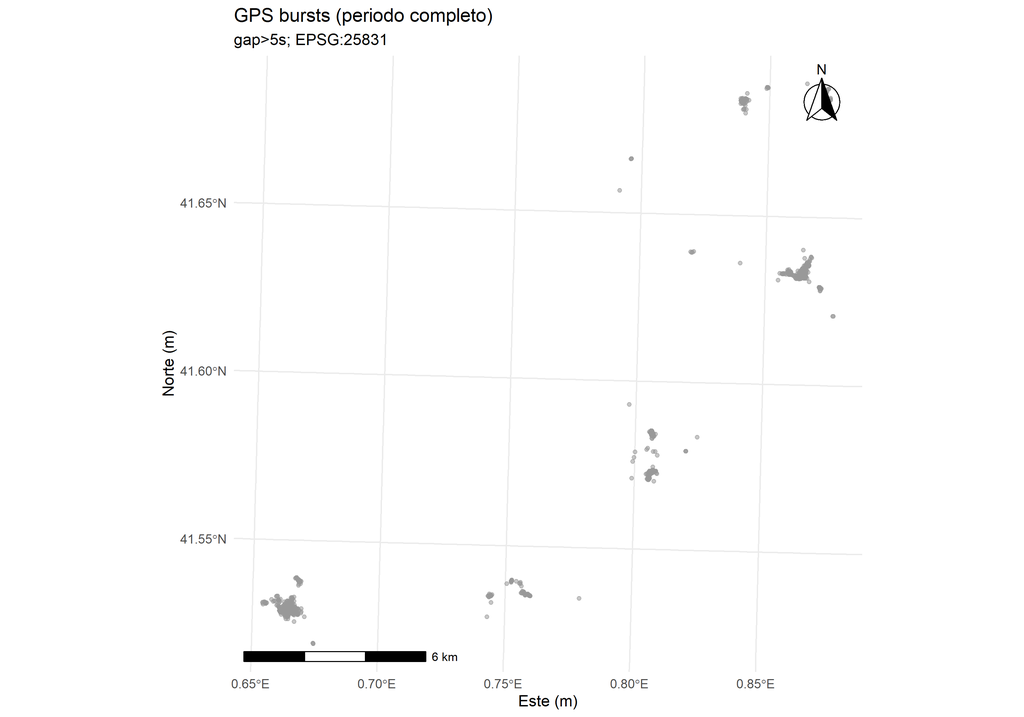

```r
beh_levels <- c("resting","foraging","courtship","alert",
                "locomotion","locomotion_fast","locomotion_slow","lying","no_ACC_match")
beh_cols <- c(
  resting="#F8766D", foraging="#7CAE00", courtship="#C49A00", alert="#00BFC4",
  locomotion="#00BA38", locomotion_fast="#00A9FF", locomotion_slow="#619CFF",
  lying="#C77CFF", no_ACC_match="grey80"
)

df_map_all <- gps_bursts_behavior %>%
  filter(!is.na(lon_med), !is.na(lat_med)) %>%
  st_as_sf(coords = c("lon_med","lat_med"), crs = 4326, remove = FALSE) %>%
  st_transform(25831) %>%
  mutate(dominant_behavior = factor(dominant_behavior, levels = beh_levels))

df_map_acc <- gps_bursts_behavior_accperiod %>%
  filter(!is.na(lon_med), !is.na(lat_med)) %>%
  st_as_sf(coords = c("lon_med","lat_med"), crs = 4326, remove = FALSE) %>%
  st_transform(25831) %>%
  mutate(dominant_behavior = factor(dominant_behavior, levels = beh_levels))

bb <- st_bbox(df_map_acc)
pad <- 250
bb_pad <- bb
bb_pad[c("xmin","ymin")] <- bb_pad[c("xmin","ymin")] - pad
bb_pad[c("xmax","ymax")] <- bb_pad[c("xmax","ymax")] + pad

# Mapa GPS-only
p_gps_only <- ggplot(df_map_all) +
  geom_sf(color = "grey60", alpha = 0.55, size = 1.1) +
  coord_sf() +
  annotation_north_arrow(location = "tr", style = north_arrow_fancy_orienteering) +
  annotation_scale(location = "bl", width_hint = 0.35) +
  theme_minimal() +
  labs(
    title = "GPS bursts (periodo completo)",
    subtitle = paste0("gap>", burst_gap_sec, "s; EPSG:25831"),
    x = "Este (m)", y = "Norte (m)"
  )

p_gps_only
```

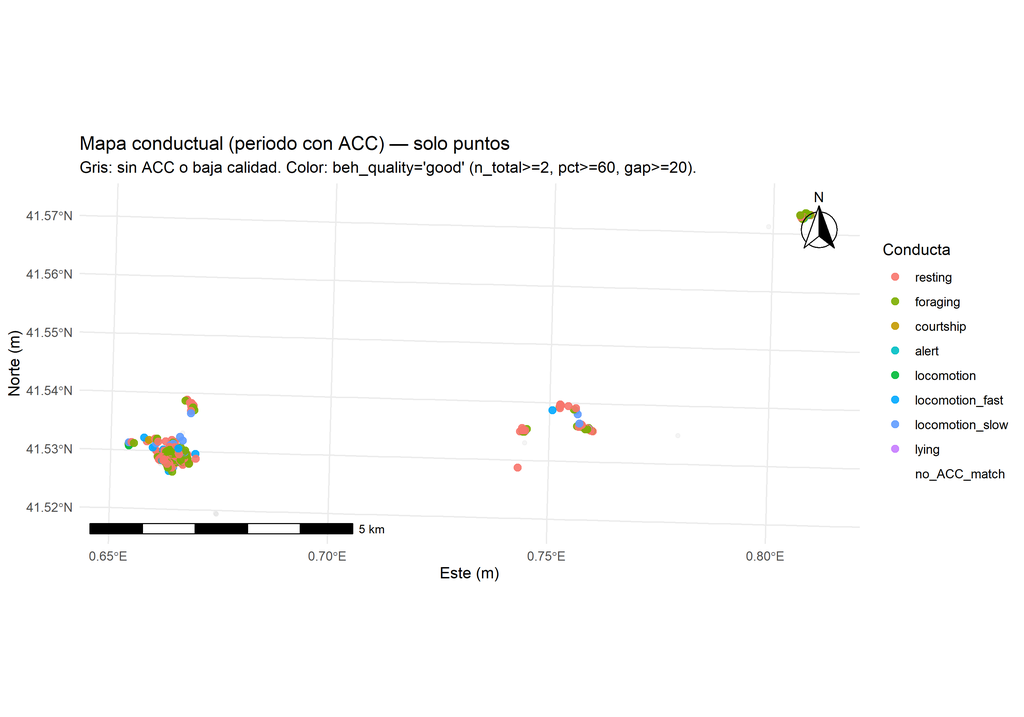

```r
ggsave(file.path(out_dir, paste0(out_prefix, "_map_GPS_only.png")),
       p_gps_only, width = 8.5, height = 6.2, dpi = 300)

# Mapa conductual (periodo ACC) con filtro de calidad
df_ok <- df_map_acc %>% filter(dominant_behavior != "no_ACC_match", beh_quality == "good")
df_ctx <- df_map_acc %>% filter(dominant_behavior == "no_ACC_match" | beh_quality != "good")

p_beh_map <- ggplot() +
  geom_sf(data = df_ctx, color = "grey85", alpha = 0.25, size = 1.2) +
  geom_sf(data = df_ok, aes(color = dominant_behavior), alpha = 0.9, size = 2.2) +
  scale_color_manual(values = beh_cols, drop = FALSE) +
  coord_sf(
    xlim = c(bb_pad["xmin"], bb_pad["xmax"]),
    ylim = c(bb_pad["ymin"], bb_pad["ymax"])
  ) +
  annotation_north_arrow(location = "tr", style = north_arrow_fancy_orienteering) +
  annotation_scale(location = "bl", width_hint = 0.35) +
  theme_minimal() +
  labs(
    title = "Mapa conductual (periodo con ACC) — solo puntos",
    subtitle = "Gris: sin ACC o baja calidad. Color: beh_quality='good' (n_total>=2, pct>=60, gap>=20).",
    x = "Este (m)", y = "Norte (m)", color = "Conducta"
  )

p_beh_map
```

```r
ggsave(file.path(out_dir, paste0(out_prefix, "_map_behavior_ACCperiod.png")),
       p_beh_map, width = 8.5, height = 6.2, dpi = 300)
```

# 6 Hotspots de *courtship* (grid 50 m) + tabla interactiva

```r
court_hot <- df_ok %>%
  filter(dominant_behavior == "courtship") %>%
  mutate(
    x = st_coordinates(geometry)[,1],
    y = st_coordinates(geometry)[,2],
    x50 = round(x / 50) * 50,
    y50 = round(y / 50) * 50
  ) %>%
  st_drop_geometry() %>%
  count(x50, y50, sort = TRUE) %>%
  mutate(cell = paste0(x50, "_", y50))

DT::datatable(
  court_hot,
  rownames = FALSE,
  extensions = c("Buttons"),
  options = list(pageLength = 15, dom = "Bfrtip", buttons = c("copy","csv","excel"), scrollX = TRUE),
  caption = "Hotspots de courtship (grid 50 m, EPSG:25831)"
)
```

| x50 | y50 | n | cell |
| --- | --- | --- | --- |
| 305100 | 4600200 | 3 | 305100_4600200 |
| 305050 | 4600200 | 2 | 305050_4600200 |
| 305200 | 4600150 | 2 | 305200_4600150 |
| 304650 | 4600450 | 1 | 304650_4600450 |
| 305150 | 4600250 | 1 | 305150_4600250 |
| 305350 | 4600100 | 1 | 305350_4600100 |

# 7 Validación ecológica: movimiento vs conducta dominante

## 7.1 Resultados descriptivos (tabla interactiva)

```r
df_beh <- gps_bursts_behavior_accperiod %>%
  filter(dominant_behavior != "no_ACC_match",
         beh_quality == "good",
         !is.na(lon_med), !is.na(lat_med)) %>%
  arrange(device_id, start_time) %>%
  group_by(device_id) %>%
  mutate(
    next_start = lead(start_time),
    next_lon   = lead(lon_med),
    next_lat   = lead(lat_med),
    gap_s = as.numeric(difftime(next_start, end_time, units = "secs")),
    dist_to_next_m = haversine_m(lon_med, lat_med, next_lon, next_lat),
    speed_to_next_m_s = dist_to_next_m / gap_s
  ) %>%
  ungroup() %>%
  filter(!is.na(gap_s), gap_s > 0, is.finite(speed_to_next_m_s))

gap_limit_min <- 30
df_beh_gap <- df_beh %>% filter(gap_s <= gap_limit_min * 60)

summary_speed <- df_beh_gap %>%
  group_by(dominant_behavior) %>%
  summarise(
    n_pairs = n(),
    med_gap_min = median(gap_s)/60,
    med_dist_m = median(dist_to_next_m, na.rm = TRUE),
    iqr_dist_m = IQR(dist_to_next_m, na.rm = TRUE),
    med_speed_m_s = median(speed_to_next_m_s, na.rm = TRUE),
    iqr_speed_m_s = IQR(speed_to_next_m_s, na.rm = TRUE),
    .groups = "drop"
  ) %>%
  arrange(desc(n_pairs))

DT::datatable(
  summary_speed,
  rownames = FALSE,
  extensions = c("Buttons"),
  options = list(pageLength = 20, dom = "Bfrtip", buttons = c("copy","csv","excel"), scrollX = TRUE),
  caption = paste0("Resumen ecológico (gap ≤ ", gap_limit_min, " min): distancia y velocidad hacia el siguiente burst")
)
```

| dominant_behavior | n_pairs | med_gap_min | med_dist_m | iqr_dist_m | med_speed_m_s | iqr_speed_m_s |
| --- | --- | --- | --- | --- | --- | --- |
| resting | 450 | 10.11666666666667 | 17.16800968662287 | 27.0890102055768 | 0.02530296339438633 | 0.03806266210343466 |
| foraging | 214 | 10.13333333333333 | 24.62869763932242 | 37.08123772872693 | 0.0343434432335311 | 0.05526473292424052 |
| locomotion_slow | 31 | 10.13333333333333 | 61.76536613142385 | 59.14283838943299 | 0.09294779632763374 | 0.08347336327199364 |
| alert | 23 | 10.13333333333333 | 39.57688177584754 | 56.20861390175183 | 0.04977177946145323 | 0.07834400446135704 |
| locomotion_fast | 11 | 10.11666666666667 | 157.9527252322514 | 205.7803018605523 | 0.1771789818006743 | 0.3156023613347793 |
| courtship | 6 | 10.28333333333333 | 33.31508102738626 | 48.32516791726423 | 0.05372704408128058 | 0.07906335197215918 |
| locomotion | 2 | 10.15 | 38.241491647563 | 21.5744386454199 | 0.06267824517582656 | 0.03522016774231239 |
| lying | 1 | 10.1 | 17.96972094144002 | 0 | 0.02965300485386142 | 0 |

## 7.2 Figura: boxplot de velocidad

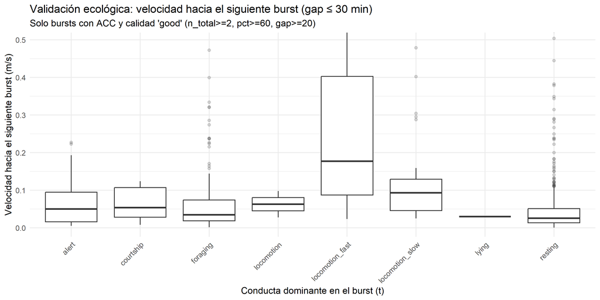

```r
p_speed <- ggplot(df_beh_gap, aes(x = dominant_behavior, y = speed_to_next_m_s)) +
  geom_boxplot(outlier.alpha = 0.2) +
  coord_cartesian(ylim = quantile(df_beh_gap$speed_to_next_m_s, c(0, 0.99), na.rm = TRUE)) +
  theme_minimal() +
  theme(axis.text.x = element_text(angle = 45, hjust = 1)) +
  labs(
    title = paste0("Validación ecológica: velocidad hacia el siguiente burst (gap ≤ ", gap_limit_min, " min)"),
    subtitle = "Solo bursts con ACC y calidad 'good' (n_total>=2, pct>=60, gap>=20)",
    x = "Conducta dominante en el burst (t)",
    y = "Velocidad hacia el siguiente burst (m/s)"
  )

p_speed
```

## 7.3 Inferencia robusta (n mínimo por clase) + resultados

```r
suppressPackageStartupMessages({
  library(FSA)
})

min_n <- 20
df_test <- df_beh_gap %>%
  group_by(dominant_behavior) %>%
  mutate(n_pairs = n()) %>%
  ungroup() %>%
  filter(n_pairs >= min_n) %>%
  mutate(dominant_behavior = droplevels(factor(dominant_behavior)))

DT::datatable(
  df_test %>% count(dominant_behavior, name = "n_pairs"),
  rownames = FALSE,
  caption = paste0("Clases incluidas en inferencia robusta (n_pairs ≥ ", min_n, ")")
)
```

| dominant_behavior | n_pairs |
| --- | --- |
| alert | 23 |
| foraging | 214 |
| locomotion_slow | 31 |
| resting | 450 |

```r
kw <- kruskal.test(speed_to_next_m_s ~ dominant_behavior, data = df_test)
kw
```

```
##
##  Kruskal-Wallis rank sum test
##
## data:  speed_to_next_m_s by dominant_behavior
## Kruskal-Wallis chi-squared = 45.851, df = 3, p-value = 6.101e-10
```

```r
dunn <- FSA::dunnTest(speed_to_next_m_s ~ dominant_behavior, data = df_test, method = "bh")
dunn$res
```

| Comparison | Z | P.unadj | P.adj |
| --- | --- | --- | --- |
| alert - foraging | 0.4986898 | 6.179979e-01 | 6.179979e-01 |
| alert - locomotion_slow | -2.7194659 | 6.538744e-03 | 9.808116e-03 |
| foraging - locomotion_slow | -4.4638264 | 8.050880e-06 | 2.415264e-05 |
| alert - resting | 1.8415549 | 6.554028e-02 | 7.864834e-02 |
| foraging - resting | 3.4232053 | 6.188732e-04 | 1.237746e-03 |
| locomotion_slow - resting | 6.1505359 | 7.722155e-10 | 4.633293e-09 |

# 8 Mapas por conducta (facets)

[figure not shown]

```r
focus_beh <- c("resting","foraging","courtship")
df_ok_focus <- df_ok %>%
  filter(dominant_behavior %in% focus_beh) %>%
  mutate(dominant_behavior = factor(dominant_behavior, levels = focus_beh))

beh_cols_focus <- c(resting="#F8766D", foraging="#7CAE00", courtship="#C49A00")

p_facets_col <- ggplot() +
  geom_sf(data = df_ctx, color = "grey88", alpha = 0.25, size = 1.1) +
  geom_sf(data = df_ok_focus, aes(color = dominant_behavior), alpha = 0.9, size = 2.2) +
  scale_color_manual(values = beh_cols_focus) +
  facet_wrap(~ dominant_behavior, nrow = 1) +
  coord_sf(
    xlim = c(bb_pad["xmin"], bb_pad["xmax"]),
    ylim = c(bb_pad["ymin"], bb_pad["ymax"])
  ) +
  annotation_north_arrow(location = "tr", style = north_arrow_fancy_orienteering) +
  annotation_scale(location = "bl", width_hint = 0.35) +
  theme_minimal() +
  labs(
    title = "Mapa por conducta (facets) — periodo con ACC",
    subtitle = "Gris: sin ACC o baja calidad. Color: bursts 'good' por conducta.",
    x = "Este (m)", y = "Norte (m)",
    color = "Conducta"
  )

p_facets_col
```

```r
ggsave(
  filename = file.path(out_dir, paste0(out_prefix, "_map_facets_rest_forage_court.png")),
  plot = p_facets_col,
  width = 11, height = 4.2, dpi = 300
)
```

# 9 Discusión (interpretación “humana”)

1. **Separar GPS-only vs GPS+ACC fue esencial.** El GPS cubre todo el periodo, pero la ACC solo está disponible en un subperiodo; si no se separa, los “no_ACC_match” pueden confundirse con ausencia de conducta cuando en realidad es ausencia de sensores.
2. **La etiqueta `beh_quality` ordena el ruido.** Muchos bursts pueden tener pocas ventanas ACC o una dominancia débil; al filtrar a `good` se obtiene un mapa más interpretable y un análisis más coherente, aunque se reduce cobertura.
3. **La validación ecológica respalda la plausibilidad.** En el resumen descriptivo aparece un gradiente claro:  
   *resting* < *foraging* < locomoción (especialmente `locomotion_slow/fast`) en velocidad.  
   Este patrón es el esperado si el comportamiento está capturando diferencias reales de actividad.
4. **Resultados inferenciales (robustos).** Al restringir el test a clases con `n_pairs ≥ 20`, el post-hoc Dunn (BH) mostró diferencias significativas entre `locomotion_slow` vs (`resting`, `foraging`, `alert`) y entre `foraging` vs `resting`, lo cual es consistente con hipótesis ecológicas.
5. **Limitación importante:** clases raras como `courtship` pueden quedar con poco n en análisis de movimiento entre ráfagas; su interpretación espacial (hotspots) se mantiene como exploratoria y debería validarse con más datos u observación.

# 10 Conclusión

La integración GPS–ACC mediante bursts permite conectar **uso de espacio** con **conducta** de manera reproducible y cartográficamente sólida (UTM 31N, norte y escala, sin fondos externos). La estructura de movimiento observada por conducta aporta una validación ecológica consistente y ayuda a sostener la plausibilidad del producto conductual en libertad, con cautela en clases raras y en bursts de baja calidad.